# Enrichment analysis on real data

Matteo Calgaro

Compiled: 18 maggio, 2020

```r
knitr::opts_chunk$set(echo = TRUE)
```

# Data loading

Biological knowledge about microbial niches has been collected in literature for some of the datasets used in the concordance analysis:

- https://www.ncbi.nlm.nih.gov/pubmed/31076212
- https://github.com/waldronlab/nychanesmicrobiome/blob/master/inst/extdata/biosis.tsv

```r
load(file = "../data/16Sdatasets_for_replicability_filtered.RData")
load(file = "../data/WMSdatasets_for_replicability_filtered.RData")
genera_methabolism <- read.table(file = "../data/genera_methabolism.tsv",sep = "\t",header = TRUE)
```

# Supragingival vs Subgingival Plaque

It is of interest to perform an enrichment analysis on the lists of differential abundant genera to study the aerobic or anaerobic methabolism of genera colonizing supragingival and subgingival plaque.

```r
grp1 = "Subgingival Plaque"
grp2 = "Supragingival Plaque"
ps <- ps_list_16S$Subgingival_Supragingival

ps@sam_data$grp = factor(ps@sam_data$HMP_BODY_SUBSITE,levels = c(grp1,grp2),labels = c("grp1","grp2"))

# Genera metadata about methabolism
methabolism_df <- data.frame(GENUS = ps@tax_table@.Data[,"GENUS"],row.names = names(ps@tax_table@.Data[,"GENUS"]))
index_meth <- match(methabolism_df$GENUS,genera_methabolism$Genera)
methabolism_df$Meth <- genera_methabolism$Meth[index_meth]

if(!file.exists("../data/supragingival_subgingival_DA.RData")){
  eval_methods <- oneSimRunGSOwn(physeq = ps,epsilon = 1e14,
                                 grid.keepX = c(seq(from = ntaxa(ps)*0.05,to = ntaxa(ps),by = 10)))
  ### Songbird data preparation
  ## OTU table
  write.table(x = "#OTU ID\t",
              file = "./songbird/supragingival_subgingival_otutable.tsv",
              quote = FALSE,
              row.names = FALSE,
              col.names = FALSE,
              eol = "")
  write.table(x = ps@otu_table, append = TRUE,
              file = "./songbird/supragingival_subgingival_otutable.tsv",
              quote = FALSE,
              sep = "\t",
              row.names = TRUE,
              col.names = TRUE)
  ## Sample data
  write.table(x = "sampleID\t",
              file = "./songbird/supragingival_subgingival_samdata.tsv",
              quote = FALSE,
              row.names = FALSE,
              col.names = FALSE,
              eol = "")
  write.table(x = ps@sam_data,
              append = TRUE,
              file = "./songbird/supragingival_subgingival_samdata.tsv",
              quote = FALSE,
              sep = "\t",
              row.names = TRUE,
              col.names = TRUE)

  ## Then switch to unix bash to run songbird:
  # module load Anaconda/2019.07
  # source activate songbird_env
  # biom convert -i './songbird/supragingival_subgingival_otutable.tsv' -o './songbird/supragingival_subgingival_otutable.biom' --to-hdf5
  # songbird multinomial --input-biom './songbird/supragingival_subgingival/supragingival_subgingival_otutable.biom' \
  #                      --metadata-file './songbird/supragingival_subgingival/supragingival_subgingival_samdata.tsv' \
  #                      --formula "grp" \
  #                      --summary-dir './songbird/supragingival_subgingival/'
  ## This procedure generates the "differentials.tsv" file

  songbird <- read.table(file = "./songbird/differentials.tsv",header = TRUE)
  eval_methods$songbird$statInfo <- data.frame(songbird,row.names = songbird$featureid)

  save(eval_methods, file = "../data/supragingival_subgingival_DA.RData")
} else load(file = "../data/supragingival_subgingival_DA.RData")
```

Many methods, many outputs:

- MAST, edgeR, limma and DESeq2 based methods have “logFC” column in statInfo matrix;
- metagenomeSeq has “coef_grp2” column of statInfo matrix which represents the FC;
- scde has “ce” column of statInfo matrix which represents the conservative estimate of expression-fold change (equals to the min(abs(c(lb, ub))), or 0 if the CI crosses the 0;
- seurat has “avg_logFC” column in statInfo matrix;
- ALDEx2 has “effect” column in statInfo matrix which represents a vector containing the per-feature effect size (grp1 vs grp2);
- corncob methods has “mu.grpgrp2” coefficient which represents the FC in statInfo matrix;
- mixMC has the “value.var” column which represents the loading;
- songbird has the “grp.T.grp2.” column which contains the differentials for grp2.

For most methods a object is present. We use statInfo information to assess the differential abundance (DA) direction, while we use pValMat to count the number of DA features (corrected p-values).

```r
col_names <- c("logFC","coef_grp2","mu.grpgrp2","ce","avg_logFC","effect","value.var","grp.T.grp2.","coef")

extract_statistics <- function(method, col_names = col_names, alpha = 0.05, percent = 30, methabolism_df = methabolism_df, ps){
  which_col <- which(col_names %in% colnames(method$statInfo))
  if("pValMat" %in% names(method)){# for most methods

    # pValMat investigation for DA identification
    DA_features_index <- which(method$pValMat[,"adjP"] < alpha)
    DA_features <- names(DA_features_index)
    if(is.null(rownames(method$statInfo)))
      rownames(method$statInfo) <- rownames(method$pValMat)

  } else if(col_names[which_col] == "grp.T.grp2."){# songbird

    differentials <- method$statInfo[,c("featureid",col_names[which_col])]
    ordered_index <- order(-abs(differentials[,col_names[which_col]]))
    DA_features_index <- ordered_index[1:round(nrow(differentials)*percent/100)] # Top 10% of total taxa
    DA_features <- differentials[DA_features_index,"featureid"]

  } else if(col_names[which_col] == "value.var"){# mixMC

    DA_features <- rownames(method$statInfo)

  }

  if(col_names[which_col] == "coef"){# corncob methods have melted statInfo matrix

    which_col <- which(col_names %in% method$statInfo$coef)
    method$statInfo <- method$statInfo[method$statInfo$coef == col_names[which_col],c("feature","Estimate")]
    colnames(method$statInfo) <- c("feature",col_names[which_col])
    rownames(method$statInfo) <- method$statInfo$feature

  }

  if(col_names[which_col] %in% c("coef_grp2","ce")){# metagenomeSeq has the log-odd values which have the opposite sign

    method$statInfo[,col_names[which_col]] <- -method$statInfo[,col_names[which_col]]

  }

  # statInfo investigation for DA direction
  direction <- sign(method$statInfo[DA_features,col_names[which_col]])
  direction <- factor(as.character(direction),levels = c("-1","1"),labels = c("DOWN in Supragingival","UP in Supragingival"))
  # association with genus methabolism
  # meth = methabolism_df[DA_features,"Meth"]

  df <- data.frame("Taxa" = HotLoadings.names(ps,format = "last"),row.names = rownames(otu_table(ps)))

  df$DA_features <- factor("non-DA",levels = c("non-DA","DOWN in Supragingival","UP in Supragingival"))
  df[as.character(DA_features),"DA_features"] <- direction
  df$Methabolism <- methabolism_df$Meth

  return(df)
}
```

DA features (adjusted p-value < 0.1) are extracted from the methods’ list

```r
DA_methods <- lapply(eval_methods,function(method)
  extract_statistics(method = method,
                     col_names = col_names,
                     alpha = 0.1,percent = 5,
                     methabolism_df = methabolism_df,ps = ps))
```

# Contingency tables

Contingency table are computed and graphically represented using Odds ratios and log odds ratios.

```r
create_contingency_tables <- function(method){
  method$Anaerobic <- "not Anaerobic"
  method$Anaerobic[method$Methabolism == "Anaerobic"] <- "Anaerobic"

  method$Aerobic <- "not Aerobic"
  method$Aerobic[method$Methabolism == "Aerobic"] <- "Aerobic"

  method$FAnaerobic <- "not F Anaerobic"
  method$FAnaerobic[method$Methabolism == "F Anaerobic"] <- "F Anaerobic"

  method$Unassigned  <- "Assigned"
  method$Unassigned [is.na(method$Methabolism)] <- "Unassigned"

  method$DOWN <- "not DOWN"
  method$DOWN[method$DA_features == "DOWN in Supragingival"] <- "DOWN in Supragingival"
  method$DOWN <- factor(method$DOWN, levels = c("DOWN in Supragingival","not DOWN"), ordered = TRUE)

  method$UP <- "not UP"
  method$UP[method$DA_features == "UP in Supragingival"] <- "UP in Supragingival"
  method$UP <- factor(method$UP, levels = c("UP in Supragingival","not UP"), ordered = TRUE)
  t_list <-
  list(t_anaerobic_DOWN = table(method$DOWN,method$Anaerobic),
       t_aerobic_DOWN = table(method$DOWN,method$Aerobic),
       t_fanaerobic_DOWN = table(method$DOWN,method$FAnaerobic),
       t_unassigned_DOWN  = table(method$DOWN,method$Unassigned),
       t_anaerobic_UP = table(method$UP,method$Anaerobic),
       t_aerobic_UP = table(method$UP,method$Aerobic),
       t_fanaerobic_UP = table(method$UP,method$FAnaerobic),
       t_unassigned_UP  = table(method$UP,method$Unassigned))

  t_list <- lapply(t_list,function(tab){
    if(ncol(tab) == 1){
      t <- as.table(matrix(c(0,0,0,0),nrow = 2,ncol = 2))
      rownames(t) <- rownames(tab)
      colnames(t) <- colnames(tab)
      t[,colnames(tab)] <- tab
      tab <- t
    }
    return(tab)
  })

  f_list <- lapply(t_list,function(tab){
    q = tab[1,1] # Number of DA taxa, in the class of interest
    k = sum(tab[1,]) # Number DA taxa
    m = sum(tab[,1]) # Number of taxa in the class of interest
    n = sum(tab[,2]) # Number of taxa not in the class of interest
    if(q > 0){
      p_value = phyper(q = q-1, m = m, k = k, n = n,lower.tail = FALSE)
    } else p_value = 1
    f <- fisher.test(tab) # Haldane-Anscombe correction
    f$p.value = p_value
    return(f)
  })
  names(f_list) <- sapply(names(f_list),gsub,pattern = "t_",replacement = "f_")

  ci_list <- lapply(t_list,function(tab){
    1.96*sqrt(sum(1/(tab)))
  })
  names(ci_list) <- sapply(names(ci_list),gsub,pattern = "t_",replacement = "ci_")

  return(c(t_list,f_list,ci_list))
}

plot_contingency_table <- function(methabolism, method_name, direction){
  ggplot(data = contingency_table_melted[contingency_table_melted$variable %in% c(methabolism,paste0("not ",methabolism)) & contingency_table_melted$Method == method_name &  grepl(pattern = direction,contingency_table_melted$Direction),],mapping = aes(x = variable, y = Direction, fill = value)) +
    geom_tile(width = 0.8, height = 0.8) +
    geom_label(aes(label = value), fill = "white") +
    coord_fixed() +
    theme_minimal() +
    scale_x_discrete(position = "top") +
    ylab(label = element_blank()) +
    theme(legend.position = "none",
          axis.title.x = element_blank()) +
    ggtitle(label = element_blank(),subtitle = method_name)
}
```

```r
contingency_table_list <- lapply(DA_methods,create_contingency_tables)

# Extract counts
contingency_table_DOWN_df <- ldply(contingency_table_list,.fun = function(method){
  cbind(method$t_aerobic_DOWN,
        method$t_anaerobic_DOWN,
        method$t_fanaerobic_DOWN,
        method$t_unassigned_DOWN)
},.id = "Method")

contingency_table_UP_df <- ldply(contingency_table_list,.fun = function(method){
  cbind(method$t_aerobic_UP,
        method$t_anaerobic_UP,
        method$t_fanaerobic_UP,
        method$t_unassigned_UP)
},.id = "Method")

contingency_table_DOWN_df$Direction <- as.factor(factor(rownames(contingency_table_list$mixMC$t_anaerobic_DOWN)))
contingency_table_UP_df$Direction <- as.factor(factor(rownames(contingency_table_list$mixMC$t_anaerobic_UP)))

contingency_table_DOWN_melted <- melt(contingency_table_DOWN_df)
contingency_table_UP_melted <- melt(contingency_table_UP_df)
contingency_table_melted <- rbind(contingency_table_DOWN_melted,
                                  contingency_table_UP_melted)

contingency_table_melted$Direction <- factor(contingency_table_melted$Direction, levels = c("not DOWN","DOWN in Supragingival","not UP","UP in Supragingival"), ordered = TRUE)

odds_ratio_df_calculation <- function(method, direction, methabolism){
  vec <- paste(c("ci","f"),methabolism,direction,sep = "_")
  CI = method[[vec[1]]]
  f_CI = method[[vec[2]]]$conf.int[1:2]
  f_est = method[[vec[2]]]$estimate
  f_pvalue = method[[vec[2]]]$p.value
  return(data.frame("CI_logodds" = CI,
                    "LowerBound" = f_CI[1],
                    "UpperBound" = f_CI[2],
                    "Odds ratio" = f_est,
                    "p-value" = f_pvalue,
                    "Methabolism" = as.character(methabolism),
                    "Direction" = direction))
}

Aerobic_UP_odds_ratio_df <- ldply(contingency_table_list,.fun = function(method) odds_ratio_df_calculation(method = method,direction = "UP",methabolism = "aerobic"),.id = "Method")
Aerobic_DOWN_odds_ratio_df <- ldply(contingency_table_list,.fun = function(method) odds_ratio_df_calculation(method = method,direction = "DOWN",methabolism = "aerobic"),.id = "Method")

Anaerobic_UP_odds_ratio_df <- ldply(contingency_table_list,.fun = function(method) odds_ratio_df_calculation(method = method,direction = "UP",methabolism = "anaerobic"),.id = "Method")
Anaerobic_DOWN_odds_ratio_df <- ldply(contingency_table_list,.fun = function(method) odds_ratio_df_calculation(method = method,direction = "DOWN",methabolism = "anaerobic"),.id = "Method")

FAnaerobic_UP_odds_ratio_df <- ldply(contingency_table_list,.fun = function(method) odds_ratio_df_calculation(method = method,direction = "UP",methabolism = "fanaerobic"),.id = "Method")
FAnaerobic_DOWN_odds_ratio_df <- ldply(contingency_table_list,.fun = function(method) odds_ratio_df_calculation(method = method,direction = "DOWN",methabolism = "fanaerobic"),.id = "Method")

Unassigned_UP_odds_ratio_df <- ldply(contingency_table_list,.fun = function(method) odds_ratio_df_calculation(method = method,direction = "UP",methabolism = "unassigned"),.id = "Method")
Unassigned_DOWN_odds_ratio_df <- ldply(contingency_table_list,.fun = function(method) odds_ratio_df_calculation(method = method,direction = "DOWN",methabolism = "unassigned"),.id = "Method")

odds_ratio_df <- rbind(Aerobic_DOWN_odds_ratio_df,
                       Aerobic_UP_odds_ratio_df,
                       Anaerobic_DOWN_odds_ratio_df,
                       Anaerobic_UP_odds_ratio_df,
                       FAnaerobic_DOWN_odds_ratio_df,
                       FAnaerobic_UP_odds_ratio_df,
                       Unassigned_DOWN_odds_ratio_df,
                       Unassigned_UP_odds_ratio_df)

odds_ratio_df$Methabolism <- factor(odds_ratio_df$Methabolism, levels = c("aerobic","anaerobic","fanaerobic","unassigned"), labels = c("Aerobic","Anaerobic","F Anaerobic","Unassigned"))

odds_ratio_df$Direction <- factor(odds_ratio_df$Direction, levels = c("DOWN","UP"), labels = c("DOWN in Supragingival","UP in Supragingival"))
```

## Contingency tables

Many ASVs are not characterized at the genus level:

```r
lapply(DA_methods,function(method) {
  summary(method[method$DA_features != "non-DA",]$Methabolism)
})
```

```
## $mixMC
##     Aerobic   Anaerobic F Anaerobic        NA's
##           1          23           8          13
##
## $seurat_wilcoxon
##     Aerobic   Anaerobic F Anaerobic        NA's
##           2          22          10          11
##
## $scde
##     Aerobic   Anaerobic F Anaerobic        NA's
##           2           6           0           3
##
## $MAST
##     Aerobic   Anaerobic F Anaerobic        NA's
##           0           8           1           3
##
## $corncob_LRT
##     Aerobic   Anaerobic F Anaerobic        NA's
##           5          40          11           4
##
## $corncob_wald
##     Aerobic   Anaerobic F Anaerobic        NA's
##          16          79          29          11
##
## $ALDEx2
##     Aerobic   Anaerobic F Anaerobic        NA's
##           0           1           0           1
##
## $mgsZig_CSS
##     Aerobic   Anaerobic F Anaerobic        NA's
##          62         147          68          28
##
## $DESeq2_TMM
##     Aerobic   Anaerobic F Anaerobic        NA's
##           6          52          19          13
##
## $DESeq2_poscounts_zinbwave
##     Aerobic   Anaerobic F Anaerobic        NA's
##          14          44          14          10
##
```

[output cut: 16 more lines]

```
## $edgeR_TMM_zinbwave
##     Aerobic   Anaerobic F Anaerobic        NA's
##          26          99          25          17
##
## $edgeR_TMM_standard
##     Aerobic   Anaerobic F Anaerobic        NA's
##          18         103          26          17
##
## $edgeR_TMM_robustDisp
##     Aerobic   Anaerobic F Anaerobic        NA's
##          34         108          53          24
##
## $songbird
##     Aerobic   Anaerobic F Anaerobic        NA's
##           0          31           5           6
```

Considering the following things:

- the reference group is the **subgingival**;
- UP-regulated taxa are more abundant in **supragingival** rather than **subgingival** plaque;
- DOWN-regulated taxa are more abundant in **subgingival** rather than **supragingival** plaque;
- contingency matrix has the number of DOWN-regulated taxa as first row;
- an odds-ratio greater than 1 (log-odds ratio > 0) means that the odd between subgingival and supragingival taxa is greater in the considered methabolic class rather than the odd in the other class.
- we expect positive log-odds ratio for the anaerobic methabolism. This is caused by the presence of more anaerobic bacteria in subgingival plaque rather than supragingival plaque.

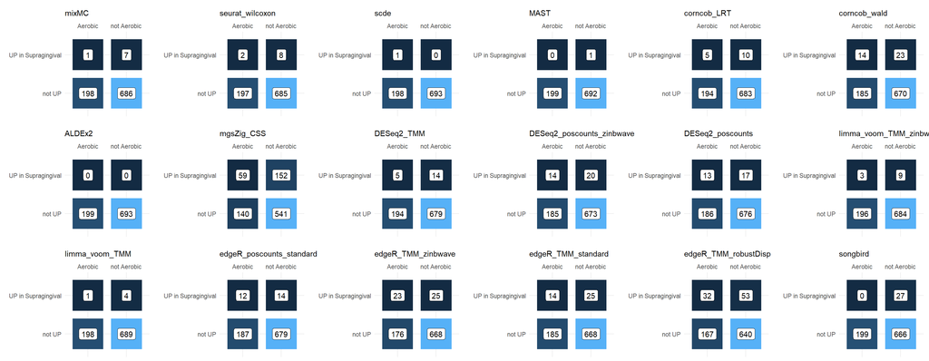

```r
plot_list_Aerobic_UP <- lapply(names(contingency_table_list),function(method) plot_contingency_table(methabolism = "Aerobic",method_name = method, direction = "UP"))
plot_list_Aerobic_DOWN <- lapply(names(contingency_table_list),function(method) plot_contingency_table(methabolism = "Aerobic",method_name = method, direction = "DOWN"))

plot_list_Anaerobic_UP <- lapply(names(contingency_table_list),function(method) plot_contingency_table(methabolism = "Anaerobic",method_name = method, direction = "UP"))
plot_list_Anaerobic_DOWN <- lapply(names(contingency_table_list),function(method) plot_contingency_table(methabolism = "Anaerobic",method_name = method, direction = "DOWN"))

plot_list_FAnaerobic_UP <- lapply(names(contingency_table_list),function(method) plot_contingency_table(methabolism = "F Anaerobic",method_name = method, direction = "UP"))
plot_list_FAnaerobic_DOWN <- lapply(names(contingency_table_list),function(method) plot_contingency_table(methabolism = "F Anaerobic",method_name = method, direction = "DOWN"))


plot_grid(plotlist = plot_list_Aerobic_UP,nrow = 3, ncol = 6)
```

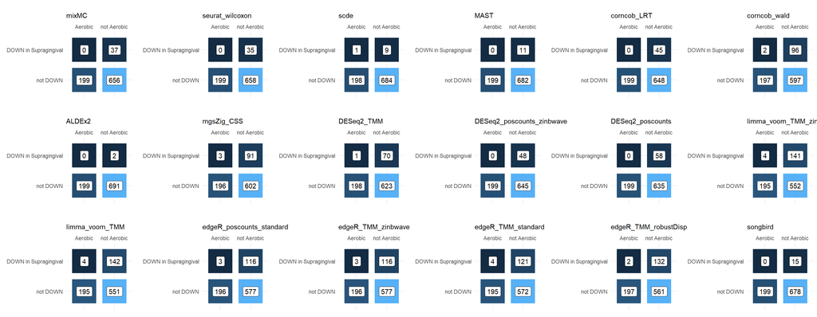

```r
plot_grid(plotlist = plot_list_Aerobic_DOWN,nrow = 3, ncol = 6)
```

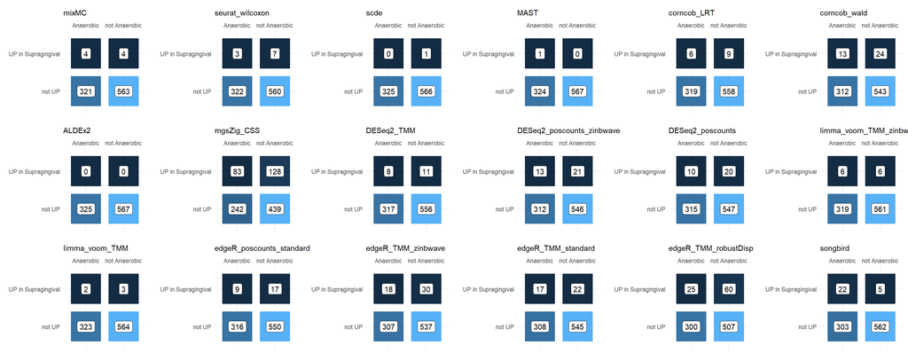

```r
plot_grid(plotlist = plot_list_Anaerobic_UP,nrow = 3, ncol = 6)
```

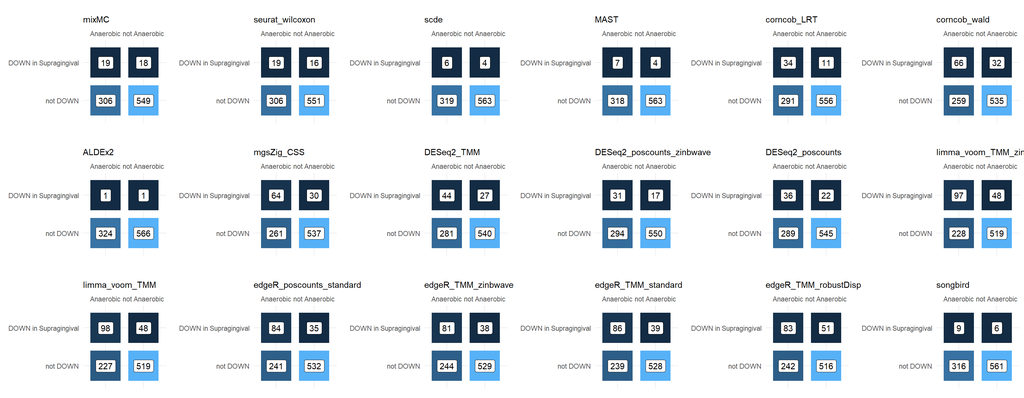

```r
plot_grid(plotlist = plot_list_Anaerobic_DOWN,nrow = 3, ncol = 6)
```

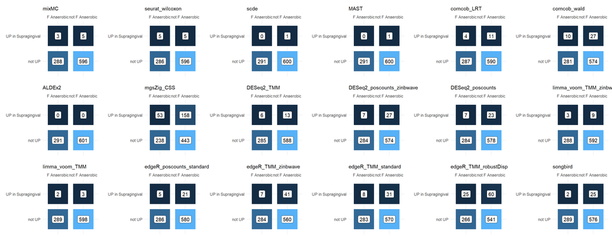

```r
plot_grid(plotlist = plot_list_FAnaerobic_UP,nrow = 3, ncol = 6)
```

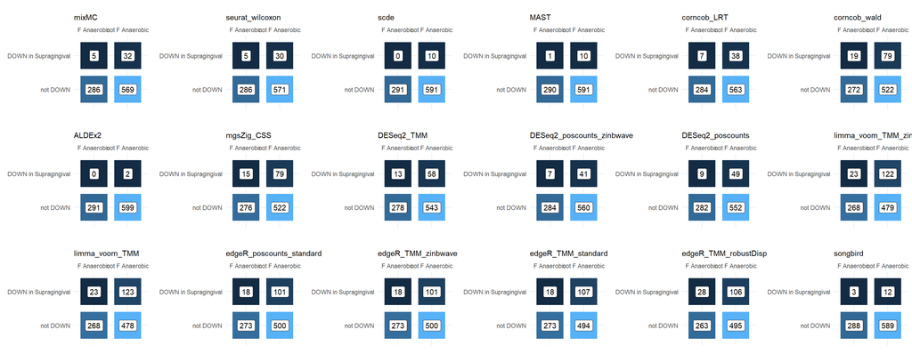

```r
plot_grid(plotlist = plot_list_FAnaerobic_DOWN,nrow = 3, ncol = 6)
```

## Summary figure

To summarize all the contingency tables, here is presented a barplot where each bar represents the value on the contingency tables in position (1,1).

An hypergeometric test is performed to inspect DA taxa enrichment in the many classes of interest.

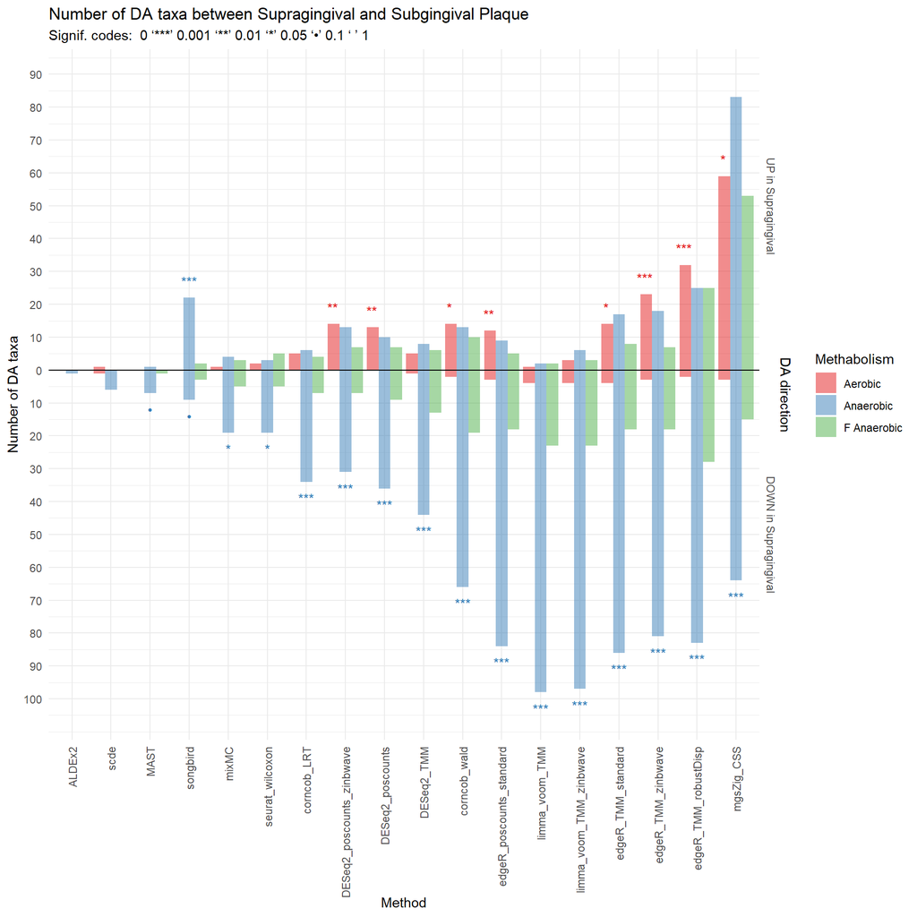

```r
data_to_plot <- contingency_table_melted %>%
  filter(Direction %in% c("DOWN in Supragingival","UP in Supragingival")) %>%
  filter(variable %in% c("Aerobic","Anaerobic","F Anaerobic","Unassigned"))

odds_ratio_to_plot <- odds_ratio_df[order(odds_ratio_df[,"Direction"]),]
data_to_plot$p_value <- odds_ratio_to_plot$p.value

ord <- order(ddply(data_to_plot,.variables = ~ Method, function(met) sum(abs(met[met$Direction %in% c("DOWN in Supragingival","UP in Supragingival"),"value"])))$V1)

# Signif. codes:  0 ‘***’ 0.001 ‘**’ 0.01 ‘*’ 0.05 ‘.’ 0.1 ‘ ’ 1

ggplot(data = data_to_plot[data_to_plot$variable != "Unassigned",], aes(x = Method,y = ifelse(Direction == "UP in Supragingival",value,-value),fill = variable)) +
  geom_col(position = "dodge",alpha = 0.5) +
  geom_text(aes(x = Method, y = ifelse(Direction == "UP in Supragingival",value+5,-value-5), label = ifelse(p_value>0.1,"",ifelse(p_value>0.05,"•",ifelse(p_value>0.01,"*",ifelse(p_value>0.001,"**","***")))), color = variable), position = position_dodge(width = 1)) +
  geom_hline(aes(yintercept = 0), color = "black") +
  scale_y_continuous(breaks = seq(-100,100,length.out = 21),labels = c(seq(from = 100,to = 0,length.out = 11),seq(from = 10,to = 100, length.out = 10)),sec.axis = sec_axis(~./50, name = "DA direction",breaks = c(-1,1),labels = c("DOWN in Supragingival","UP in Supragingival"))) +
  scale_x_discrete(limits = levels(data_to_plot$Method)[ord]) +
  theme_minimal() +
  ylab("Number of DA taxa") +
  scale_fill_manual(values = c(RColorBrewer::brewer.pal(3,"Set1"),"darkgrey")) +
  scale_color_manual(values = c(RColorBrewer::brewer.pal(3,"Set1"),"darkgrey")) +
  theme(axis.text.x = element_text(angle = 90, hjust = 1, vjust = 0.5),
        axis.text.y.right = element_text(angle = -90,hjust = 0.5)) +
  guides(fill = guide_legend(title = "Methabolism",override.aes = aes(label = "")),color = "none") +
  ggtitle("Number of DA taxa between Supragingival and Subgingival Plaque",subtitle = "Signif. codes:  0 ‘***’ 0.001 ‘**’ 0.01 ‘*’ 0.05 ‘•’ 0.1 ‘ ’ 1")
```

## Log Odds ratio

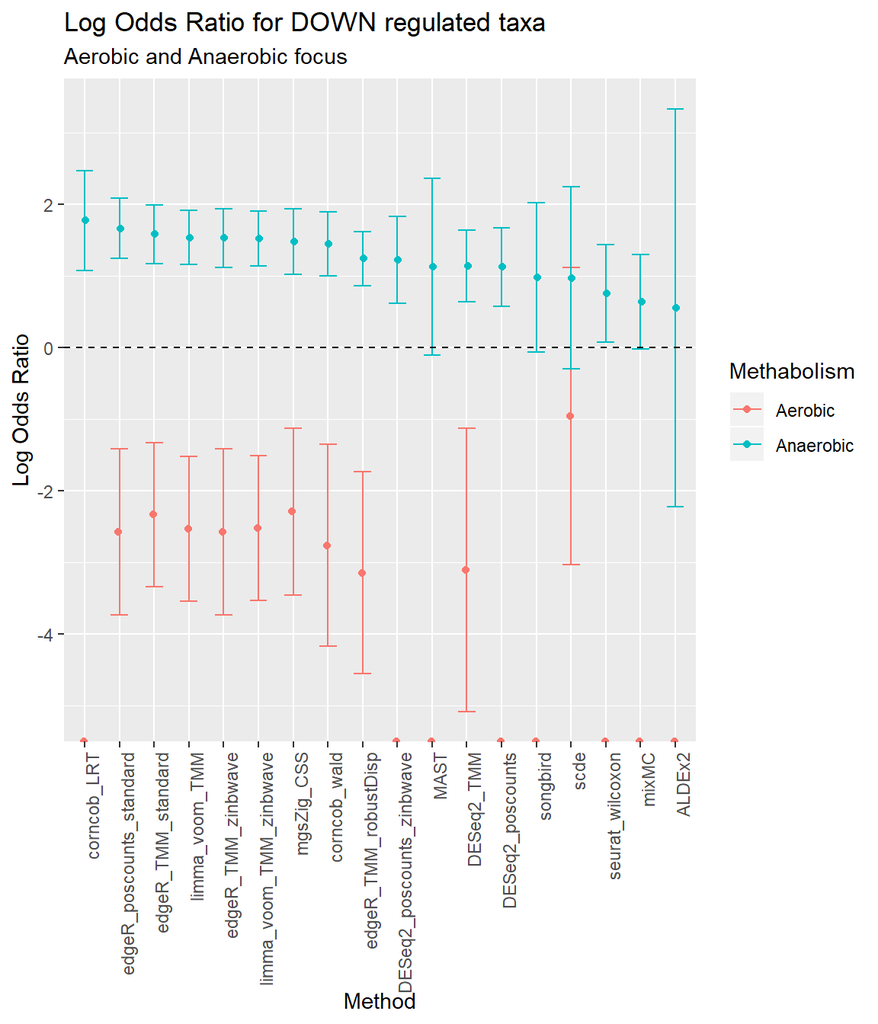

```r
ord_df <- ddply(odds_ratio_df,.variables = ~ Direction + Method, function(met) met[met$Methabolism == "Aerobic","Odds.ratio"]-met[met$Methabolism == "Anaerobic","Odds.ratio"])

ord <- order(ord_df[ord_df$Direction == "DOWN in Supragingival","V1"])

ggplot(data = odds_ratio_df %>% filter(Direction == "DOWN in Supragingival" & Methabolism %in% c("Aerobic","Anaerobic")) ,mapping = aes(x = Method, y = log(Odds.ratio), color = Methabolism)) +
  theme_grey() +
  theme(axis.text.x = element_text(angle = 90,hjust = 1)) +
  geom_point(position = position_dodge(width = 0.1)) +
  geom_errorbar(mapping = aes(ymin = log(Odds.ratio)-CI_logodds, ymax = log(Odds.ratio)+CI_logodds),width = 0.5) +
  scale_x_discrete(limits = levels(odds_ratio_df$Method)[ord]) +
  ylab("Log Odds Ratio") +
  #facet_zoom(ylim = c(-4,4),split = TRUE) +
  geom_hline(mapping = aes(yintercept = 0), color = "black", lty = 2) +
  ggtitle(label = "Log Odds Ratio for DOWN regulated taxa", subtitle = "Aerobic and Anaerobic focus")
```

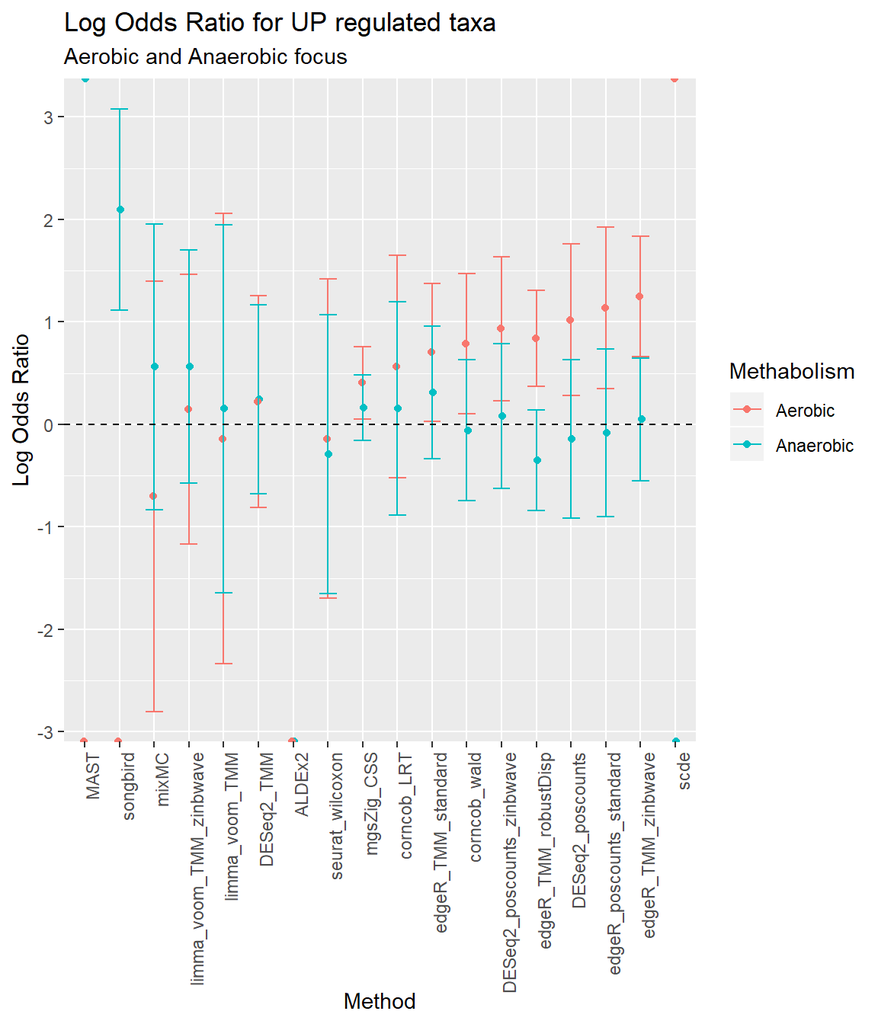

```r
ord <- order(ord_df[ord_df$Direction == "UP in Supragingival","V1"])

ggplot(data = odds_ratio_df %>% filter(Direction == "UP in Supragingival" & Methabolism %in% c("Aerobic","Anaerobic")) ,mapping = aes(x = Method, y = log(Odds.ratio), color = Methabolism)) +
  theme_grey() +
  theme(axis.text.x = element_text(angle = 90,hjust = 1)) +
  geom_point(position = position_dodge(width = 0.1)) +
  geom_errorbar(mapping = aes(ymin = log(Odds.ratio)-CI_logodds, ymax = log(Odds.ratio)+CI_logodds),width = 0.5) +
  scale_x_discrete(limits = levels(odds_ratio_df$Method)[ord]) +
  ylab("Log Odds Ratio") +
  #facet_zoom(ylim = c(-4,4),split = TRUE) +
  geom_hline(mapping = aes(yintercept = 0), color = "black", lty = 2) +
  ggtitle(label = "Log Odds Ratio for UP regulated taxa", subtitle = "Aerobic and Anaerobic focus")
```

## Odds ratio

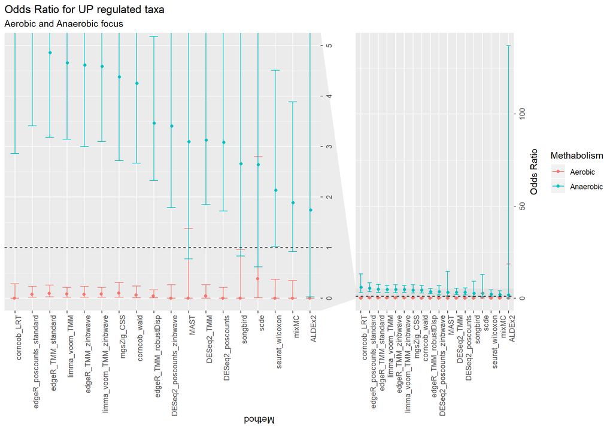

```r
ord_df <- ddply(odds_ratio_df,.variables = ~ Direction + Method, function(met) met[met$Methabolism == "Aerobic","Odds.ratio"]-met[met$Methabolism == "Anaerobic","Odds.ratio"])

ord <- order(ord_df[ord_df$Direction == "DOWN in Supragingival","V1"])

ggplot(data = odds_ratio_df %>% filter(Direction == "DOWN in Supragingival" & Methabolism %in% c("Aerobic","Anaerobic")) ,mapping = aes(x = Method, y = Odds.ratio, color = Methabolism)) +
  theme_grey() +
  theme(axis.text.x = element_text(angle = 90,hjust = 1),
        axis.text.y.right = element_text(angle = 90,hjust = 0.5),
        axis.title.y.right = element_text(angle = 90),
        axis.title.x = element_text(angle = 180)) +
  geom_point(position = position_dodge(width = 0.1)) +
  geom_errorbar(mapping = aes(ymin = LowerBound, ymax = UpperBound),width = 0.5) +
  scale_x_discrete(limits = levels(odds_ratio_df$Method)[ord]) +
  scale_y_continuous(position = "right") +
  ylab("Odds Ratio") +
  facet_zoom(ylim = c(0,5),split = TRUE) +
  geom_hline(mapping = aes(yintercept = 1), color = "black", lty = 2) +
  ggtitle(label = "Odds Ratio for UP regulated taxa", subtitle = "Aerobic and Anaerobic focus")
```

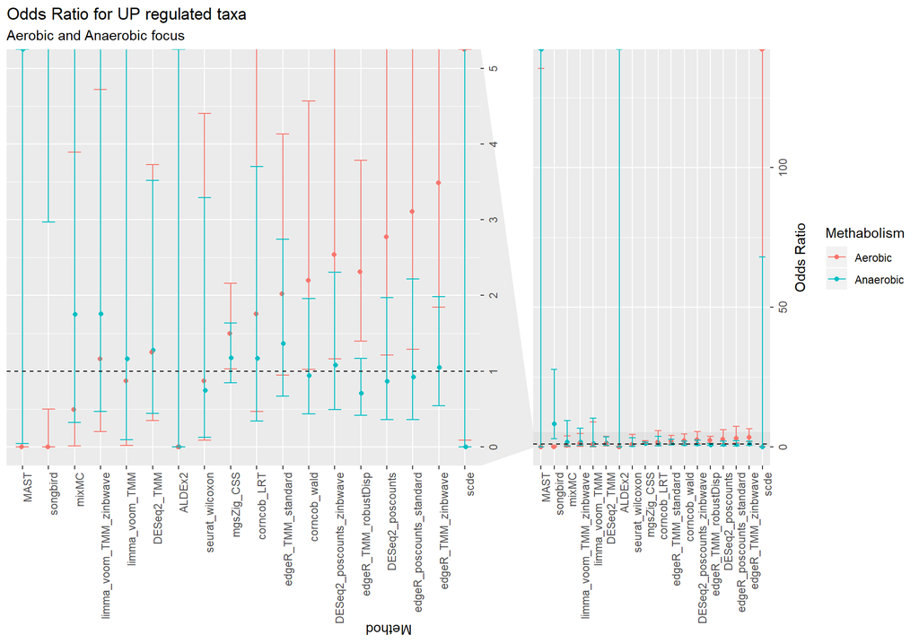

```r
ord <- order(ord_df[ord_df$Direction == "UP in Supragingival","V1"])

ggplot(data = odds_ratio_df %>% filter(Direction == "UP in Supragingival" & Methabolism %in% c("Aerobic","Anaerobic")) ,mapping = aes(x = Method, y = Odds.ratio, color = Methabolism)) +
  theme_grey() +
  theme(axis.text.x = element_text(angle = 90,hjust = 1),
        axis.text.y.right = element_text(angle = 90,hjust = 0.5),
        axis.title.y.right = element_text(angle = 90),
        axis.title.x = element_text(angle = 180)) +
  geom_point(position = position_dodge(width = 0.1)) +
  geom_errorbar(mapping = aes(ymin = LowerBound, ymax = UpperBound),width = 0.5) +
  scale_x_discrete(limits = levels(odds_ratio_df$Method)[ord]) +
  scale_y_continuous(position = "right") +
  ylab("Odds Ratio") +
  facet_zoom(ylim = c(0,5),split = TRUE) +
  geom_hline(mapping = aes(yintercept = 1), color = "black", lty = 2) +
  ggtitle(label = "Odds Ratio for UP regulated taxa", subtitle = "Aerobic and Anaerobic focus")
```

## Mutual findings plot

Each method finds some DA taxa. In this plot we inspect wether they share the same findings or not.

```r
DA_methods_df <- ldply(DA_methods,function(met) met %>% filter(DA_features != "non-DA"),.id = "Method")
DA_methods_df$Compositional <- factor(DA_methods_df$Method,
                                      levels = c("mixMC",
                                                "seurat_wilcoxon",
                                                "scde",
                                                "MAST",
                                                "corncob_LRT",
                                                "corncob_wald",
                                                "ALDEx2",
                                                "mgsZig_CSS",
                                                "DESeq2_TMM",
                                                "DESeq2_poscounts_zinbwave",
                                                "DESeq2_poscounts",
                                                "limma_voom_TMM_zinbwave",
                                                "limma_voom_TMM",
                                                "edgeR_poscounts_standard",
                                                "edgeR_TMM_zinbwave",
                                                "edgeR_TMM_standard",
                                                "edgeR_TMM_robustDisp",
                                                "songbird"),
                                      labels = c("Compositional","Non-Compositional","Non-Compositional","Non-Compositional","Non-Compositional","Non-Compositional",
                                                 "Compositional","Non-Compositional","Non-Compositional","Non-Compositional","Non-Compositional","Non-Compositional",
                                                 "Non-Compositional","Non-Compositional","Non-Compositional","Non-Compositional","Non-Compositional","Compositional"))

DA_methods_df$Tech <- factor(DA_methods_df$Method,
                                      levels = c("mixMC",
                                                "seurat_wilcoxon",
                                                "scde",
                                                "MAST",
                                                "corncob_LRT",
                                                "corncob_wald",
                                                "ALDEx2",
                                                "mgsZig_CSS",
                                                "DESeq2_TMM",
                                                "DESeq2_poscounts_zinbwave",
                                                "DESeq2_poscounts",
                                                "limma_voom_TMM_zinbwave",
                                                "limma_voom_TMM",
                                                "edgeR_poscounts_standard",
                                                "edgeR_TMM_zinbwave",
                                                "edgeR_TMM_standard",
                                                "edgeR_TMM_robustDisp",
                                                "songbird"),
                                      labels = c("metagenomics","sc-RNAseq","sc-RNAseq","sc-RNAseq","metagenomics","metagenomics",
                                                 "metagenomics","metagenomics","RNAseq","sc-RNAseq","RNAseq","sc-RNAseq",
                                                 "RNAseq","RNAseq","sc-RNAseq","RNAseq","RNAseq","metagenomics"))

length(unique(DA_methods_df$Taxa))
```

```
## [1] 389
```

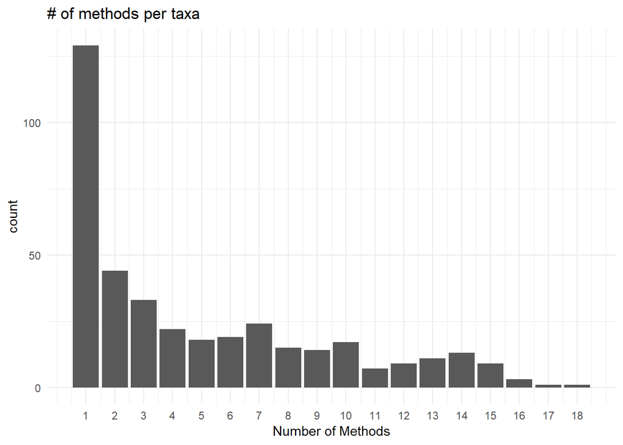

```r
taxa_by_method <- ddply(DA_methods_df,.variables = ~ Taxa, .fun = function(taxa) nrow(taxa))
colnames(taxa_by_method) <- c("Taxa","Number of methods")
ggplot(taxa_by_method,aes(x = `Number of methods`)) +
  geom_bar(width = 0.9) +
  theme_minimal() +
  scale_x_continuous(breaks = 1:18) +
  xlab("Number of Methods") +
  ggtitle("# of methods per taxa")
```

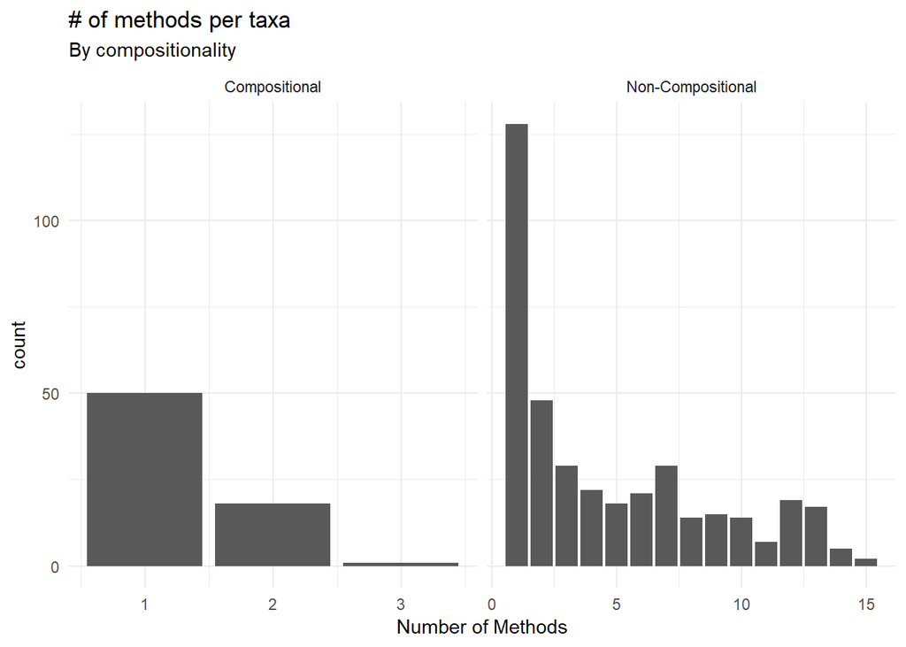

```r
taxa_by_method <- ddply(DA_methods_df,.variables = ~ Taxa + Compositional, .fun = function(taxa) nrow(taxa))
colnames(taxa_by_method) <- c("Taxa","Compositional","Number of methods")
ggplot(taxa_by_method,aes(x = `Number of methods`)) +
  geom_bar(width = 0.9) +
  facet_grid(~ Compositional,scales = "free_x") +
  theme_minimal() +
  xlab("Number of Methods") +
  ggtitle("# of methods per taxa",subtitle = "By compositionality")
```

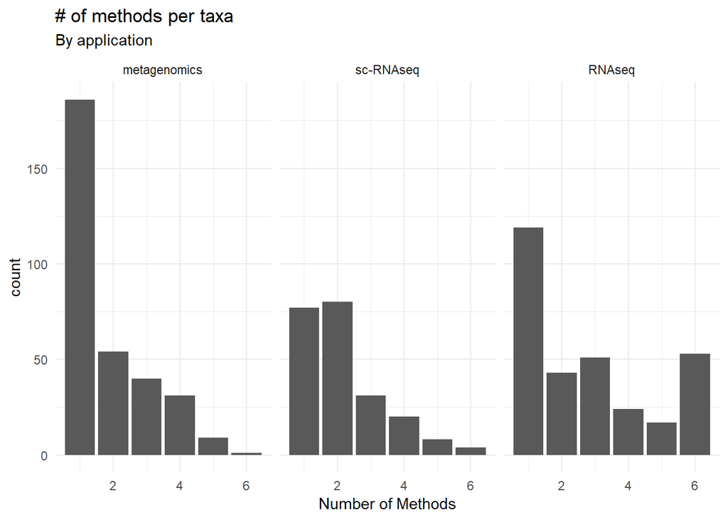

```r
taxa_by_method <- ddply(DA_methods_df,.variables = ~ Taxa + Tech, .fun = function(taxa) nrow(taxa))
colnames(taxa_by_method) <- c("Taxa","Tech","Number of methods")
ggplot(taxa_by_method,aes(x = `Number of methods`)) +
  geom_bar(width = 0.9) +
  facet_grid(~ Tech,scales = "free_x") +
  theme_minimal() +
  xlab("Number of Methods") +
  ggtitle("# of methods per taxa",subtitle = "By application")
```

389 Unique taxa out of 892 are found as DA from one or more method.However only a minority are mutually found by all of them.

```r
mutual_findings <- function(DA_methods_df, min_num = 5, DA_feat, Meth, compositional = c("Compositional","Non-Compositional"), tech = c("metagenomics","sc-RNAseq","RNAseq")){

  DA_methods_df <- DA_methods_df %>% filter(Tech %in% tech & Compositional %in% compositional)

  taxa_by_method <- ddply(DA_methods_df,.variables = ~ Taxa, .fun = function(taxa) nrow(taxa))
  taxa_to_plot <- taxa_by_method %>% filter(V1 >= min_num)

  df_to_plot <- DA_methods_df %>% filter(Taxa %in% taxa_to_plot$Taxa) %>% filter(Methabolism %in% Meth & DA_features %in% DA_feat)

  y_lab <- ddply(df_to_plot,.variables = ~ Taxa, .fun = function(taxa) nrow(taxa))
  ord_y <- order(y_lab$V1,decreasing = TRUE)

  x_lab <- ddply(df_to_plot,.variables = ~ Method, .fun = function(met) nrow(met))
  ord_x <- order(x_lab$V1,decreasing = TRUE)

  last_name <- HotLoadings.names(ps,format = "last")

  ggplot(data = df_to_plot,aes(x = Method, y = Taxa, fill = DA_features)) +
    geom_tile(width = 0.9, height = 0.9) +
    facet_grid(~ Methabolism) +
    theme_minimal() +
    theme(axis.text.x = element_text(angle = 90, hjust = 1, vjust = 0.5)) +
    scale_y_discrete(limits = y_lab$Taxa[ord_y]) +
    scale_x_discrete(limits = x_lab$Method[ord_x]) +
    coord_equal() +
    ggtitle(label = paste0("Mutual findings for methods - ",Meth," methabolism Taxa"),subtitle = paste0("Features identified in ",min_num," or more ",ifelse(length(compositional)==2,"",paste0(" ", compositional)),ifelse(length(tech)==3,"",paste0(" ",tech))," Methods"))
}
```

### Aerobic

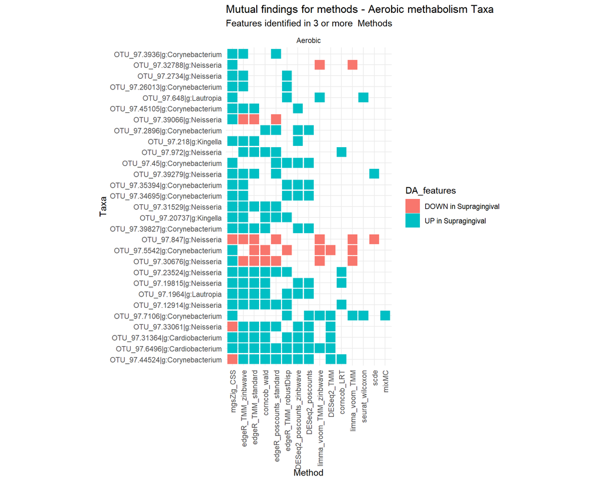

```r
mutual_findings(DA_methods_df,min_num = 3,DA_feat = c("DOWN in Supragingival","UP in Supragingival"),Meth = "Aerobic")
```

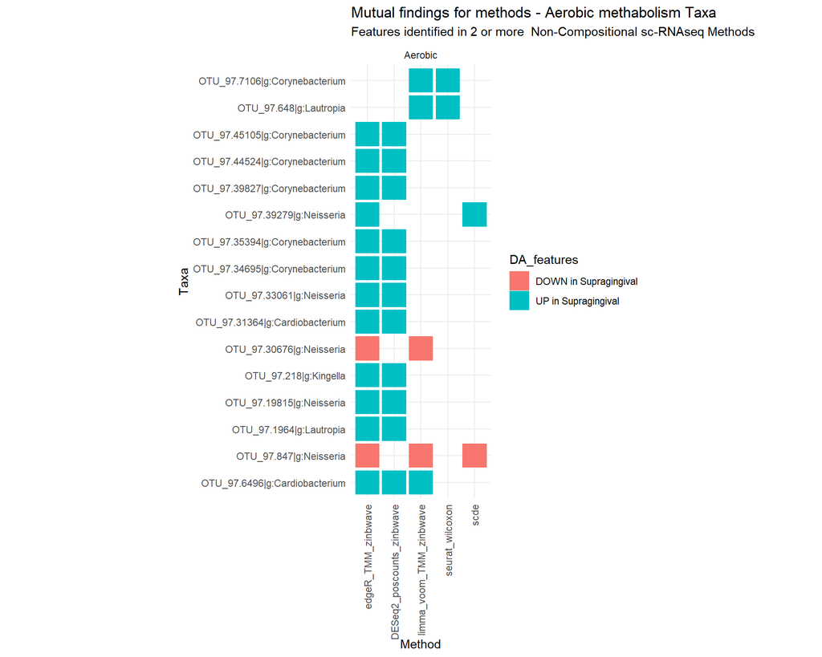

```r
mutual_findings(DA_methods_df,min_num = 2,DA_feat = c("DOWN in Supragingival","UP in Supragingival"),Meth = "Aerobic",tech = "sc-RNAseq",compositional = "Non-Compositional")
```

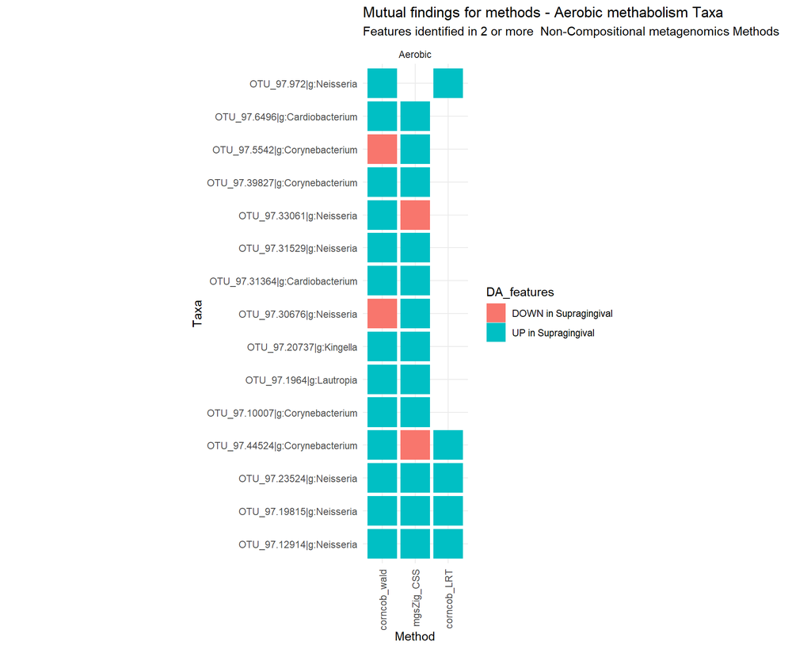

```r
mutual_findings(DA_methods_df,min_num = 2,DA_feat = c("DOWN in Supragingival","UP in Supragingival"),Meth = "Aerobic",tech = "metagenomics",compositional = "Non-Compositional")
```

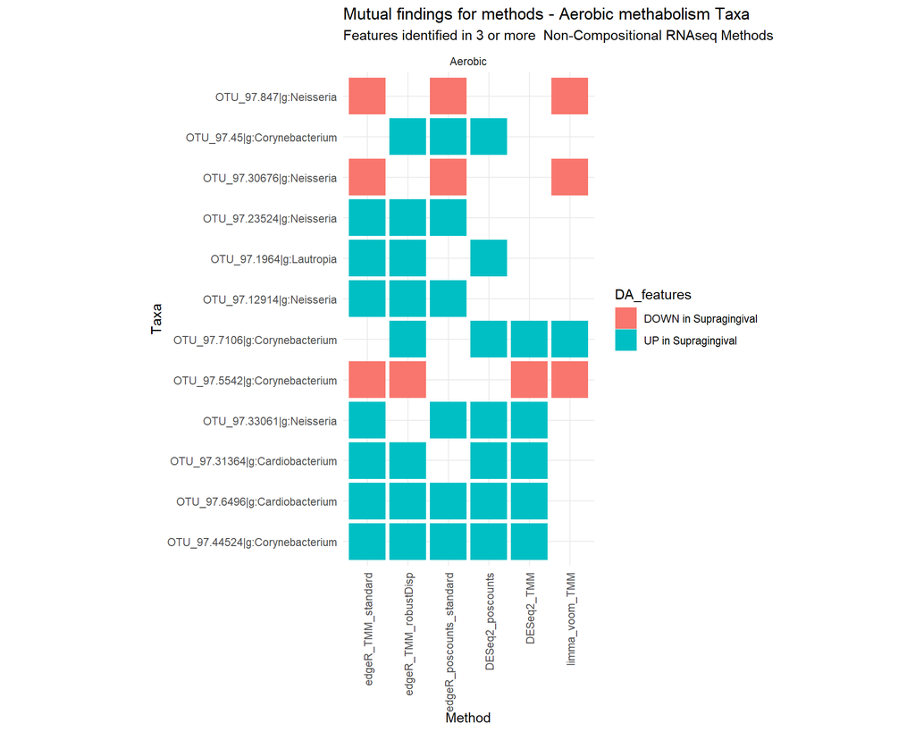

```r
mutual_findings(DA_methods_df,min_num = 3,DA_feat = c("DOWN in Supragingival","UP in Supragingival"),Meth = "Aerobic",tech = "RNAseq",compositional = "Non-Compositional")
```

### Anaerobic

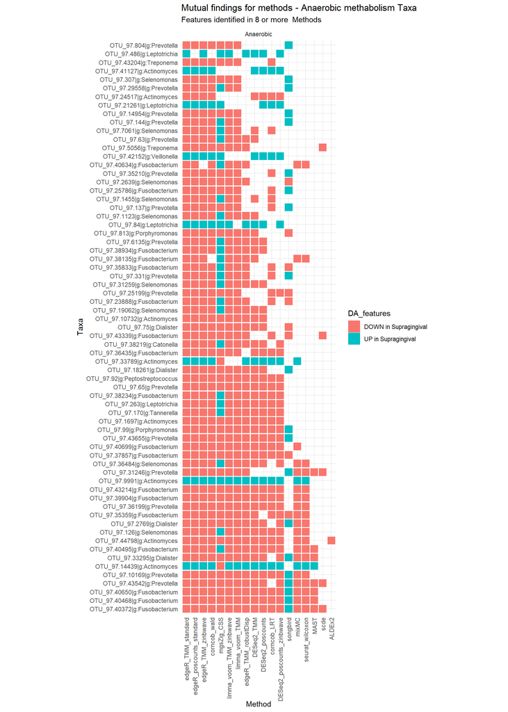

```r
mutual_findings(DA_methods_df,min_num = 8,DA_feat = c("DOWN in Supragingival","UP in Supragingival"),Meth = "Anaerobic")
```

### F Anaerobic

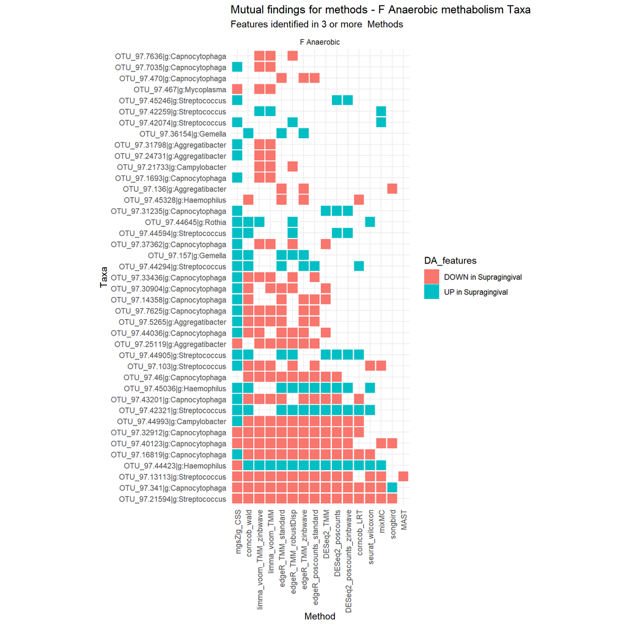

```r
mutual_findings(DA_methods_df,min_num = 3,DA_feat = c("DOWN in Supragingival","UP in Supragingival"),Meth = "F Anaerobic")
```